# R Code for Chapter 4 of Introduction to Data Mining: Classification: Alternative Techniques

Michael Hahsler

2021-04-02

This code covers chapter 4 of *“Introduction to Data Mining”* by Pang-Ning Tan, Michael Steinbach and Vipin Kumar. **See [table of contents](https://github.com/mhahsler/Introduction_to_Data_Mining_R_Examples#readme) for code examples for other chapters.**

This work is licensed under the [Creative Commons Attribution 4.0 International License](http://creativecommons.org/licenses/by/4.0/). For questions please contact [Michael Hahsler](http://michael.hahsler.net).

We will use tidyverse to prepare the data.

```r
library(tidyverse)
```

Show fewer digits

```r
options(digits=3)
```

# Load the Zoo Dataset and Create a Training Set

We will use the Zoo dataset which is included in the R package `mlbench` (you may have to install it). The Zoo dataset containing 17 (mostly logical) variables on different 101 animals as a data frame with 17 columns (hair, feathers, eggs, milk, airborne, aquatic, predator, toothed, backbone, breathes, venomous, fins, legs, tail, domestic, catsize, type). We convert the data frame into a tidyverse tibble (optional).

```r
data(Zoo, package="mlbench")
Zoo <- as_tibble(Zoo)
Zoo
```

```
## # A tibble: 101 x 17
##    hair  feathers eggs  milk  airborne aquatic predator toothed backbone
##    <lgl> <lgl>    <lgl> <lgl> <lgl>    <lgl>   <lgl>    <lgl>   <lgl>
##  1 TRUE  FALSE    FALSE TRUE  FALSE    FALSE   TRUE     TRUE    TRUE
##  2 TRUE  FALSE    FALSE TRUE  FALSE    FALSE   FALSE    TRUE    TRUE
##  3 FALSE FALSE    TRUE  FALSE FALSE    TRUE    TRUE     TRUE    TRUE
##  4 TRUE  FALSE    FALSE TRUE  FALSE    FALSE   TRUE     TRUE    TRUE
##  5 TRUE  FALSE    FALSE TRUE  FALSE    FALSE   TRUE     TRUE    TRUE
##  6 TRUE  FALSE    FALSE TRUE  FALSE    FALSE   FALSE    TRUE    TRUE
##  7 TRUE  FALSE    FALSE TRUE  FALSE    FALSE   FALSE    TRUE    TRUE
##  8 FALSE FALSE    TRUE  FALSE FALSE    TRUE    FALSE    TRUE    TRUE
##  9 FALSE FALSE    TRUE  FALSE FALSE    TRUE    TRUE     TRUE    TRUE
## 10 TRUE  FALSE    FALSE TRUE  FALSE    FALSE   FALSE    TRUE    TRUE
## # … with 91 more rows, and 8 more variables: breathes <lgl>, venomous <lgl>,
## #   fins <lgl>, legs <int>, tail <lgl>, domestic <lgl>, catsize <lgl>,
## #   type <fct>
```

We will use the package [**caret**](https://topepo.github.io/caret/) to make preparing training sets and building classification (and regression) models easier. A great cheat sheet can be found [here](https://ugoproto.github.io/ugo_r_doc/pdf/caret.pdf).

```r
library(caret)
```

Use multi-core support for cross-validation. **Note:** It is commented out because it does not work with rJava used in RWeka below.

```r
#library(doMC, quietly = TRUE)
#registerDoMC(cores = 4)
#getDoParWorkers()
```

Test data is not used in the model building process and needs to be set aside purely for testing the model after it is completely built. Here I use 80% for training.

```r
inTrain <- createDataPartition(y = Zoo$type, p = .8, list = FALSE)
Zoo_train <- Zoo %>% slice(inTrain)
Zoo_test <- Zoo %>% slice(-inTrain)
```

# Fitting Different Classification Models to the Training Data

Create a fixed sampling scheme (10-folds) so we can compare the fitted models later.

```r
train_index <- createFolds(Zoo_train$type, k = 10)
```

The fixed folds are used in `train()` with the argument `trControl = trainControl(method = "cv", indexOut = train_index))`. If you don’t need fixed folds, then remove `indexOut = train_index` in the code below.

For help with building models in caret see: `? train`

**Note:** Be careful if you have many `NA` values in your data. `train()` and cross-validation many fail in some cases. If that is the case then you can remove features (columns) which have many `NA`s, omit `NA`s using `na.omit()` or use imputation to replace them with reasonable values (e.g., by the feature mean or via kNN). Highly imbalanced datasets are also problematic since there is a chance that a fold does not contain examples of each class leading to a hard to understand error message.

## Conditional Inference Tree (Decision Tree)

```r
ctreeFit <- Zoo_train %>% train(type ~ .,
  method = "ctree",
  data = .,
    tuneLength = 5,
    trControl = trainControl(method = "cv", indexOut = train_index))
ctreeFit
```

```
## Conditional Inference Tree
##
## 83 samples
## 16 predictors
##  7 classes: 'mammal', 'bird', 'reptile', 'fish', 'amphibian', 'insect', 'mollusc.et.al'
##
## No pre-processing
## Resampling: Cross-Validated (10 fold)
## Summary of sample sizes: 75, 73, 74, 74, 74, 76, ...
## Resampling results across tuning parameters:
##
##   mincriterion  Accuracy  Kappa
##   0.010         0.823     0.769
##   0.255         0.823     0.769
##   0.500         0.823     0.769
##   0.745         0.823     0.769
##   0.990         0.823     0.769
##
## Accuracy was used to select the optimal model using the largest value.
## The final value used for the model was mincriterion = 0.99.
```

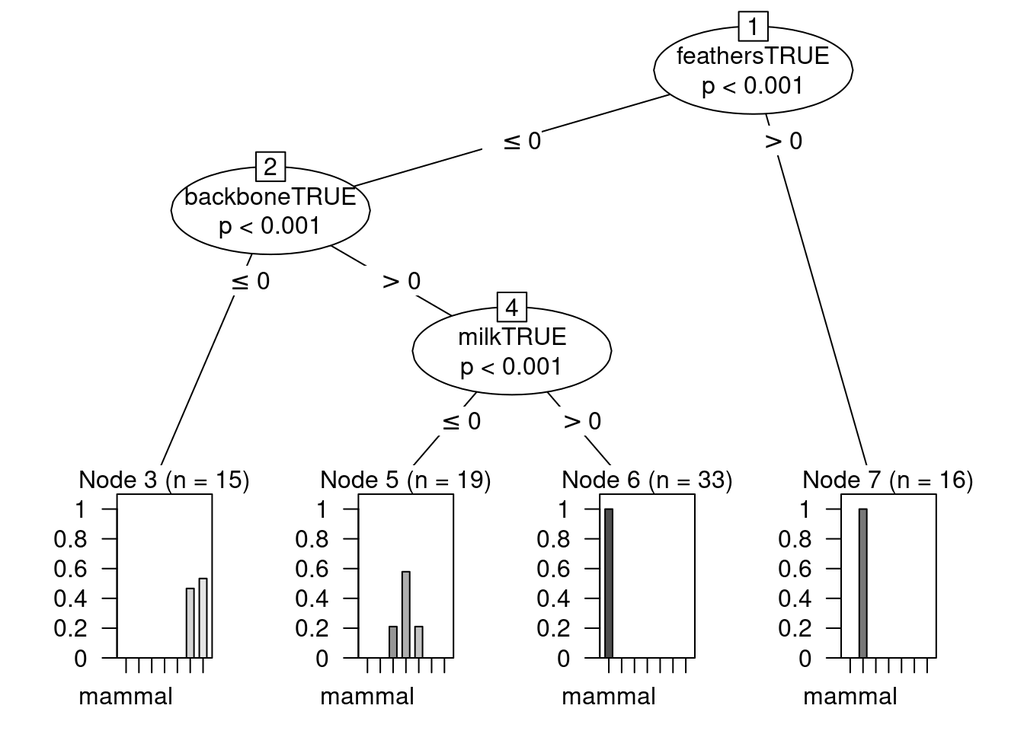

```r
plot(ctreeFit$finalModel)
```

The final model can be directly used for predict()

```r
predict(ctreeFit, head(Zoo_test))
```

```
## [1] mammal        mollusc.et.al bird          mammal        fish
## [6] mammal
## Levels: mammal bird reptile fish amphibian insect mollusc.et.al
```

## C 4.5 Decision Tree

```r
library(RWeka)
C45Fit <- Zoo_train %>% train(type ~ .,
  method = "J48",
  data = .,
    tuneLength = 5,
    trControl = trainControl(method = "cv", indexOut = train_index))
C45Fit
```

```
## C4.5-like Trees
##
## 83 samples
## 16 predictors
##  7 classes: 'mammal', 'bird', 'reptile', 'fish', 'amphibian', 'insect', 'mollusc.et.al'
##
## No pre-processing
## Resampling: Cross-Validated (10 fold)
## Summary of sample sizes: 74, 74, 75, 76, 75, 76, ...
## Resampling results across tuning parameters:
##
##   C      M  Accuracy  Kappa
##   0.010  1  0.966     0.957
##   0.010  2  0.966     0.957
##   0.010  3  0.968     0.958
##   0.010  4  0.954     0.941
##   0.010  5  0.937     0.917
##   0.133  1  0.966     0.957
##   0.133  2  0.966     0.957
##   0.133  3  0.968     0.958
##   0.133  4  0.954     0.941
##   0.133  5  0.937     0.917
##   0.255  1  0.976     0.970
##   0.255  2  0.976     0.970
##   0.255  3  0.968     0.958
##   0.255  4  0.954     0.941
##   0.255  5  0.937     0.917
##   0.378  1  0.976     0.970
##   0.378  2  0.976     0.970
##   0.378  3  0.968     0.958
##   0.378  4  0.954     0.941
##   0.378  5  0.937     0.917
##   0.500  1  0.976     0.970
##   0.500  2  0.976     0.970
##   0.500  3  0.968     0.958
##   0.500  4  0.954     0.941
##   0.500  5  0.937     0.917
##
## Accuracy was used to select the optimal model using the largest value.
## The final values used for the model were C = 0.255 and M = 1.
```

```r
C45Fit$finalModel
```

```
## J48 pruned tree
## ------------------
##
## feathersTRUE <= 0
## |   milkTRUE <= 0
## |   |   backboneTRUE <= 0
## |   |   |   aquaticTRUE <= 0
## |   |   |   |   legs <= 2: mollusc.et.al (2.0)
## |   |   |   |   legs > 2: insect (7.0)
## |   |   |   aquaticTRUE > 0: mollusc.et.al (6.0)
## |   |   backboneTRUE > 0
## |   |   |   finsTRUE <= 0
## |   |   |   |   aquaticTRUE <= 0: reptile (3.0)
## |   |   |   |   aquaticTRUE > 0
## |   |   |   |   |   eggsTRUE <= 0: reptile (1.0)
## |   |   |   |   |   eggsTRUE > 0: amphibian (4.0)
## |   |   |   finsTRUE > 0: fish (11.0)
## |   milkTRUE > 0: mammal (33.0)
## feathersTRUE > 0: bird (16.0)
##
## Number of Leaves  :  9
##
## Size of the tree :   17
```

## K-Nearest Neighbors

**Note:** kNN uses Euclidean distance, so data should be standardized (scaled) first. Here legs are measured between 0 and 6 while all other variables are between 0 and 1. Scaling can be directly performed as preprocessing in `train` using the parameter `preProcess = "scale"`.

```r
knnFit <- Zoo_train %>% train(type ~ .,
  method = "knn",
  data = .,
  preProcess = "scale",
    tuneLength = 5,
  tuneGrid=data.frame(k = 1:10),
    trControl = trainControl(method = "cv", indexOut = train_index))
knnFit
```

```
## k-Nearest Neighbors
##
## 83 samples
## 16 predictors
##  7 classes: 'mammal', 'bird', 'reptile', 'fish', 'amphibian', 'insect', 'mollusc.et.al'
##
## Pre-processing: scaled (16)
## Resampling: Cross-Validated (10 fold)
## Summary of sample sizes: 76, 75, 74, 74, 75, 77, ...
## Resampling results across tuning parameters:
##
##   k   Accuracy  Kappa
##    1  1.000     1.000
##    2  0.973     0.963
##    3  0.973     0.963
##    4  0.927     0.904
##    5  0.951     0.933
##    6  0.963     0.949
##    7  0.925     0.897
##    8  0.879     0.836
##    9  0.889     0.850
##   10  0.821     0.760
##
## Accuracy was used to select the optimal model using the largest value.
## The final value used for the model was k = 1.
```

```r
knnFit$finalModel
```

```
## 1-nearest neighbor model
## Training set outcome distribution:
##
##        mammal          bird       reptile          fish     amphibian
##            33            16             4            11             4
##        insect mollusc.et.al
##             7             8
```

## PART (Rule-based classifier)

```r
rulesFit <- Zoo_train %>% train(type ~ .,
  method = "PART",
  data = .,
  tuneLength = 5,
  trControl = trainControl(method = "cv", indexOut = train_index))
rulesFit
```

```
## Rule-Based Classifier
##
## 83 samples
## 16 predictors
##  7 classes: 'mammal', 'bird', 'reptile', 'fish', 'amphibian', 'insect', 'mollusc.et.al'
##
## No pre-processing
## Resampling: Cross-Validated (10 fold)
## Summary of sample sizes: 76, 74, 74, 75, 74, 71, ...
## Resampling results across tuning parameters:
##
##   threshold  pruned  Accuracy  Kappa
##   0.010      yes     0.956     0.944
##   0.010      no      0.978     0.971
##   0.133      yes     0.956     0.944
##   0.133      no      0.978     0.971
##   0.255      yes     0.956     0.944
##   0.255      no      0.978     0.971
##   0.378      yes     0.956     0.944
##   0.378      no      0.978     0.971
##   0.500      yes     0.956     0.944
##   0.500      no      0.978     0.971
##
## Accuracy was used to select the optimal model using the largest value.
## The final values used for the model were threshold = 0.5 and pruned = no.
```

```r
rulesFit$finalModel
```

```
## PART decision list
## ------------------
##
## feathersTRUE <= 0 AND
## milkTRUE > 0: mammal (33.0)
##
## feathersTRUE > 0: bird (16.0)
##
## backboneTRUE <= 0 AND
## airborneTRUE <= 0 AND
## aquaticTRUE > 0: mollusc.et.al (6.0)
##
## backboneTRUE <= 0 AND
## legs > 2: insect (7.0)
##
## finsTRUE > 0: fish (11.0)
##
## backboneTRUE > 0 AND
## aquaticTRUE <= 0: reptile (3.0)
##
## aquaticTRUE > 0 AND
## venomousTRUE <= 0: amphibian (3.0)
##
## aquaticTRUE <= 0: mollusc.et.al (2.0)
##
## : reptile (2.0/1.0)
##
## Number of Rules  :   9
```

## Linear Support Vector Machines

```r
svmFit <- Zoo_train %>% train(type ~.,
  method = "svmLinear",
  data = .,
    tuneLength = 5,
    trControl = trainControl(method = "cv", indexOut = train_index))
svmFit
```

```
## Support Vector Machines with Linear Kernel
##
## 83 samples
## 16 predictors
##  7 classes: 'mammal', 'bird', 'reptile', 'fish', 'amphibian', 'insect', 'mollusc.et.al'
##
## No pre-processing
## Resampling: Cross-Validated (10 fold)
## Summary of sample sizes: 72, 74, 76, 77, 75, 75, ...
## Resampling results:
##
##   Accuracy  Kappa
##   1         1
##
## Tuning parameter 'C' was held constant at a value of 1
```

```r
svmFit$finalModel
```

```
## Support Vector Machine object of class "ksvm"
##
## SV type: C-svc  (classification)
##  parameter : cost C = 1
##
## Linear (vanilla) kernel function.
##
## Number of Support Vectors : 35
##
## Objective Function Value : -0.143 -0.215 -0.15 -0.175 -0.0934 -0.0972 -0.253 -0.0822 -0.146 -0.0913 -0.0996 -0.182 -0.592 -0.133 -0.151 -0.119 -0.048 -0.0823 -0.125 -0.148 -0.443
## Training error : 0
```

## Random Forest

```r
randomForestFit <- Zoo_train %>% train(type ~ .,
  method = "rf",
  data = .,
    tuneLength = 5,
    trControl = trainControl(method = "cv", indexOut = train_index))
randomForestFit
```

```
## Random Forest
##
## 83 samples
## 16 predictors
##  7 classes: 'mammal', 'bird', 'reptile', 'fish', 'amphibian', 'insect', 'mollusc.et.al'
##
## No pre-processing
## Resampling: Cross-Validated (10 fold)
## Summary of sample sizes: 74, 75, 74, 75, 75, 76, ...
## Resampling results across tuning parameters:
##
##   mtry  Accuracy  Kappa
##    2    1.000     1.000
##    5    0.989     0.986
##    9    0.989     0.986
##   12    0.989     0.986
##   16    0.989     0.986
##
## Accuracy was used to select the optimal model using the largest value.
## The final value used for the model was mtry = 2.
```

```r
randomForestFit$finalModel
```

```
##
## Call:
##  randomForest(x = x, y = y, mtry = param$mtry)
##                Type of random forest: classification
##                      Number of trees: 500
## No. of variables tried at each split: 2
##
##         OOB estimate of  error rate: 6.02%
## Confusion matrix:
##               mammal bird reptile fish amphibian insect mollusc.et.al
## mammal            33    0       0    0         0      0             0
## bird               0   16       0    0         0      0             0
## reptile            0    1       0    2         1      0             0
## fish               0    0       0   11         0      0             0
## amphibian          0    0       0    0         4      0             0
## insect             0    0       0    0         0      7             0
## mollusc.et.al      0    0       0    0         0      1             7
##               class.error
## mammal              0.000
## bird                0.000
## reptile             1.000
## fish                0.000
## amphibian           0.000
## insect              0.000
## mollusc.et.al       0.125
```

## Gradient Boosted Decision Trees (xgboost)

```r
xgboostFit <- Zoo_train %>% train(type ~ .,
  method = "xgbTree",
  data = .,
  tuneLength = 5,
  trControl = trainControl(method = "cv", indexOut = train_index),
  tuneGrid = expand.grid(
    nrounds = 20,
    max_depth = 3,
    colsample_bytree = .6,
    eta = 0.1,
    gamma=0,
    min_child_weight = 1,
    subsample = .5
  ))
xgboostFit
```

```
## eXtreme Gradient Boosting
##
## 83 samples
## 16 predictors
##  7 classes: 'mammal', 'bird', 'reptile', 'fish', 'amphibian', 'insect', 'mollusc.et.al'
##
## No pre-processing
## Resampling: Cross-Validated (10 fold)
## Summary of sample sizes: 73, 76, 76, 75, 76, 72, ...
## Resampling results:
##
##   Accuracy  Kappa
##   0.99      0.987
##
## Tuning parameter 'nrounds' was held constant at a value of 20
## Tuning
##  held constant at a value of 1
## Tuning parameter 'subsample' was held
##  constant at a value of 0.5
```

```r
xgboostFit$finalModel
```

```
## ##### xgb.Booster
## raw: 85.8 Kb
## call:
##   xgboost::xgb.train(params = list(eta = param$eta, max_depth = param$max_depth,
##     gamma = param$gamma, colsample_bytree = param$colsample_bytree,
##     min_child_weight = param$min_child_weight, subsample = param$subsample),
##     data = x, nrounds = param$nrounds, num_class = length(lev),
##     objective = "multi:softprob")
## params (as set within xgb.train):
##   eta = "0.1", max_depth = "3", gamma = "0", colsample_bytree = "0.6", min_child_weight = "1", subsample = "0.5", num_class = "7", objective = "multi:softprob", validate_parameters = "TRUE"
## xgb.attributes:
##   niter
## callbacks:
##   cb.print.evaluation(period = print_every_n)
## # of features: 16
## niter: 20
## nfeatures : 16
## xNames : hairTRUE feathersTRUE eggsTRUE milkTRUE airborneTRUE aquaticTRUE predatorTRUE toothedTRUE backboneTRUE breathesTRUE venomousTRUE finsTRUE legs tailTRUE domesticTRUE catsizeTRUE
## problemType : Classification
## tuneValue :
##    nrounds max_depth eta gamma colsample_bytree min_child_weight subsample
## 1      20         3 0.1     0              0.6                1       0.5
## obsLevels : mammal bird reptile fish amphibian insect mollusc.et.al
## param :
##  list()
```

## Artificial Neural Network

```r
nnetFit <- Zoo_train %>% train(type ~ .,
  method = "nnet",
  data = .,
    tuneLength = 5,
    trControl = trainControl(method = "cv", indexOut = train_index),
  trace = FALSE)
nnetFit
```

```
## Neural Network
##
## 83 samples
## 16 predictors
##  7 classes: 'mammal', 'bird', 'reptile', 'fish', 'amphibian', 'insect', 'mollusc.et.al'
##
## No pre-processing
## Resampling: Cross-Validated (10 fold)
## Summary of sample sizes: 76, 73, 74, 73, 76, 74, ...
## Resampling results across tuning parameters:
##
##   size  decay  Accuracy  Kappa
##   1     0e+00  0.708     0.596
##   1     1e-04  0.817     0.735
##   1     1e-03  0.888     0.848
```

[output cut: 25 more lines]

```r
nnetFit$finalModel
```

```
## a 16-3-7 network with 79 weights
## inputs: hairTRUE feathersTRUE eggsTRUE milkTRUE airborneTRUE aquaticTRUE predatorTRUE toothedTRUE backboneTRUE breathesTRUE venomousTRUE finsTRUE legs tailTRUE domesticTRUE catsizeTRUE
## output(s): .outcome
## options were - softmax modelling  decay=0.01
```

# Compare Models

Collect the performance metrics from the models trained on the same data.

```r
resamps <- resamples(list(
  ctree = ctreeFit,
  C45 = C45Fit,
  SVM = svmFit,
  KNN = knnFit,
  rules = rulesFit,
  randomForest = randomForestFit,
  xgboost = xgboostFit,
  NeuralNet = nnetFit
    ))
resamps
```

```
##
## Call:
## resamples.default(x = list(ctree = ctreeFit, C45 = C45Fit, SVM = svmFit, KNN
##  = knnFit, rules = rulesFit, randomForest = randomForestFit, xgboost
##  = xgboostFit, NeuralNet = nnetFit))
##
## Models: ctree, C45, SVM, KNN, rules, randomForest, xgboost, NeuralNet
## Number of resamples: 10
## Performance metrics: Accuracy, Kappa
## Time estimates for: everything, final model fit
```

Calculate summary statistics

```r
summary(resamps)
```

```
##
## Call:
## summary.resamples(object = resamps)
##
## Models: ctree, C45, SVM, KNN, rules, randomForest, xgboost, NeuralNet
## Number of resamples: 10
##
## Accuracy
##               Min. 1st Qu. Median  Mean 3rd Qu. Max. NA's
## ctree        0.625   0.783  0.817 0.823   0.875    1    0
## C45          0.875   1.000  1.000 0.976   1.000    1    0
## SVM          1.000   1.000  1.000 1.000   1.000    1    0
## KNN          1.000   1.000  1.000 1.000   1.000    1    0
## rules        0.875   1.000  1.000 0.978   1.000    1    0
## randomForest 1.000   1.000  1.000 1.000   1.000    1    0
## xgboost      0.900   1.000  1.000 0.990   1.000    1    0
## NeuralNet    1.000   1.000  1.000 1.000   1.000    1    0
##
## Kappa
##               Min. 1st Qu. Median  Mean 3rd Qu. Max. NA's
## ctree        0.529   0.723  0.748 0.769   0.836    1    0
## C45          0.840   1.000  1.000 0.970   1.000    1    0
## SVM          1.000   1.000  1.000 1.000   1.000    1    0
## KNN          1.000   1.000  1.000 1.000   1.000    1    0
## rules        0.837   1.000  1.000 0.971   1.000    1    0
## randomForest 1.000   1.000  1.000 1.000   1.000    1    0
## xgboost      0.867   1.000  1.000 0.987   1.000    1    0
## NeuralNet    1.000   1.000  1.000 1.000   1.000    1    0
```

Perform inference about differences between models. For each metric, all pair-wise differences are computed and tested to assess if the difference is equal to zero. By default Bonferroni correction for multiple comparison is used. Differences are shown in the upper triangle and p-values are in the lower triangle.

```r
difs <- diff(resamps)
difs
```

```
##
## Call:
## diff.resamples(x = resamps)
##
## Models: ctree, C45, SVM, KNN, rules, randomForest, xgboost, NeuralNet
## Metrics: Accuracy, Kappa
## Number of differences: 28
## p-value adjustment: bonferroni
```

```r
summary(difs)
```

```
##
## Call:
## summary.diff.resamples(object = difs)
##
## p-value adjustment: bonferroni
## Upper diagonal: estimates of the difference
## Lower diagonal: p-value for H0: difference = 0
##
## Accuracy
##              ctree  C45      SVM      KNN      rules    randomForest xgboost
## ctree               -0.15389 -0.17750 -0.17750 -0.15500 -0.17750     -0.16750
## C45          0.0354          -0.02361 -0.02361 -0.00111 -0.02361     -0.01361
## SVM          0.0069 1.0000             0.00000  0.02250  0.00000      0.01000
## KNN          0.0069 1.0000   NA                 0.02250  0.00000      0.01000
## rules        0.0451 1.0000   1.0000   1.0000            -0.02250     -0.01250
## randomForest 0.0069 1.0000   NA       NA       1.0000                 0.01000
## xgboost      0.0124 1.0000   1.0000   1.0000   1.0000   1.0000
## NeuralNet    0.0069 1.0000   NA       NA       1.0000   NA           1.0000
##              NeuralNet
## ctree        -0.17750
## C45          -0.02361
## SVM           0.00000
## KNN           0.00000
## rules        -0.02250
## randomForest  0.00000
## xgboost      -0.01000
## NeuralNet
##
## Kappa
##              ctree   C45       SVM       KNN       rules     randomForest
## ctree                -0.201025 -0.230871 -0.230871 -0.201387 -0.230871
## C45          0.02877           -0.029846 -0.029846 -0.000362 -0.029846
## SVM          0.00537 1.00000              0.000000  0.029484  0.000000
## KNN          0.00537 1.00000   NA                   0.029484  0.000000
## rules        0.03821 1.00000   1.00000   1.00000             -0.029484
## randomForest 0.00537 1.00000   NA        NA        1.00000
## xgboost      0.00990 1.00000   1.00000   1.00000   1.00000   1.00000
## NeuralNet    0.00537 1.00000   NA        NA        1.00000   NA
##              xgboost   NeuralNet
## ctree        -0.217538 -0.230871
## C45          -0.016513 -0.029846
## SVM           0.013333  0.000000
## KNN           0.013333  0.000000
## rules        -0.016151 -0.029484
## randomForest  0.013333  0.000000
## xgboost                -0.013333
## NeuralNet    1.00000
```

All perform similarly well except ctree (differences in the first row are negative and the p-values in the first column are <.05 indicating that the null-hypothesis of a difference of 0 can be rejected).

# Using the Chosen Model on the Test Data

Most models do similarly well on the data. We choose here the random forest model.

```r
pr <- predict(randomForestFit, Zoo_test)
pr
```

```
##  [1] mammal        mollusc.et.al bird          mammal        fish
##  [6] mammal        bird          bird          reptile       mammal
## [11] mammal        insect        mammal        mammal        bird
## [16] fish          mammal        insect
## Levels: mammal bird reptile fish amphibian insect mollusc.et.al
```

Calculate the confusion matrix for the held-out test data.

```r
confusionMatrix(Zoo_test$type, pr)
```

```
## Confusion Matrix and Statistics
##
##                Reference
## Prediction      mammal bird reptile fish amphibian insect mollusc.et.al
##   mammal             8    0       0    0         0      0             0
##   bird               0    4       0    0         0      0             0
##   reptile            0    0       1    0         0      0             0
##   fish               0    0       0    2         0      0             0
##   amphibian          0    0       0    0         0      0             0
##   insect             0    0       0    0         0      1             0
##   mollusc.et.al      0    0       0    0         0      1             1
##
## Overall Statistics
##
##                Accuracy : 0.944
##                  95% CI : (0.727, 0.999)
##     No Information Rate : 0.444
##     P-Value [Acc > NIR] : 1.08e-05
##
##                   Kappa : 0.923
##
##  Mcnemar's Test P-Value : NA
##
## Statistics by Class:
##
##                      Class: mammal Class: bird Class: reptile Class: fish
## Sensitivity                  1.000       1.000         1.0000       1.000
## Specificity                  1.000       1.000         1.0000       1.000
## Pos Pred Value               1.000       1.000         1.0000       1.000
## Neg Pred Value               1.000       1.000         1.0000       1.000
## Prevalence                   0.444       0.222         0.0556       0.111
## Detection Rate               0.444       0.222         0.0556       0.111
## Detection Prevalence         0.444       0.222         0.0556       0.111
## Balanced Accuracy            1.000       1.000         1.0000       1.000
##                      Class: amphibian Class: insect Class: mollusc.et.al
## Sensitivity                        NA        0.5000               1.0000
## Specificity                         1        1.0000               0.9412
## Pos Pred Value                     NA        1.0000               0.5000
## Neg Pred Value                     NA        0.9412               1.0000
## Prevalence                          0        0.1111               0.0556
## Detection Rate                      0        0.0556               0.0556
## Detection Prevalence                0        0.0556               0.1111
## Balanced Accuracy                  NA        0.7500               0.9706
```

# More Information

- Example using deep learning with keras.
- A visual comparison of decision boundaries.
- Package caret: http://topepo.github.io/caret/index.html
- Tidymodels (machine learning with tidyverse): https://www.tidymodels.org/
- R taskview on machine learning: http://cran.r-project.org/web/views/MachineLearning.html